# Diagnostics

## Content

1. Assumptions
2. Residual plots
3. Resolving issues
   - non-linearity
   - heteroscedasticity
   - multicollinearity

## Assumptions

Assumptions of the linear model:

- linearity
- normality
- homoscedasticity
- no outliers

## Example

We will use the following model as an example.

```
Call:
lm(formula = mpg ~ disp, data = mtcars)

Coefficients:
(Intercept)         disp
   29.59985     -0.04122
```

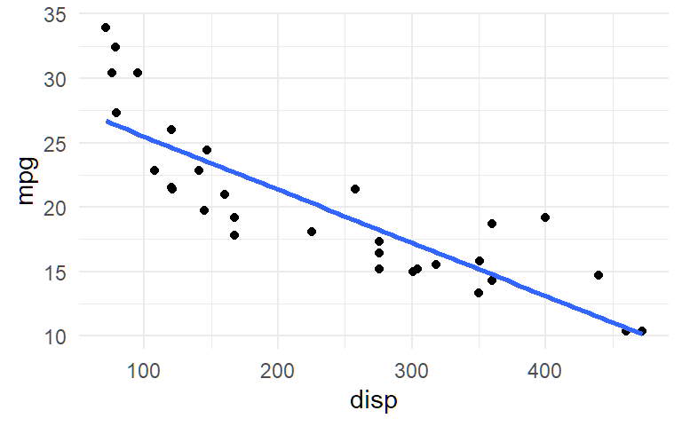

## Residual plots

## Plots generated by `lm`

| Plot | Assumption check |
| --- | --- |
| Residuals vs Fitted | Linearity |
| Scale-Location | Homoscedasticity |
| Normal Q-Q | Normality |
| Residuals vs Leverage | Influential cases |

The code is

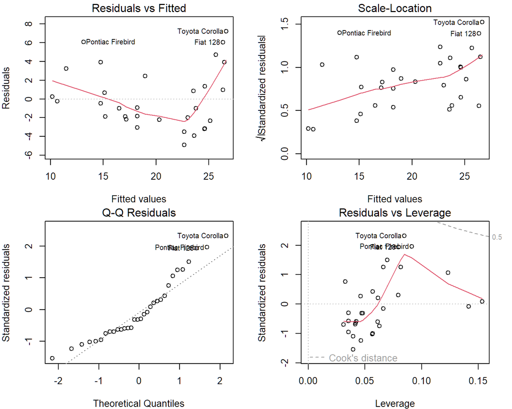

```r
par(mfrow = c(2, 2))  # to have them in one figure
plot(<lm object>)
```

## Residuals vs Fitted

**Linearity**: straight red line at 0

- Middle fitted values overestimate `mpg`

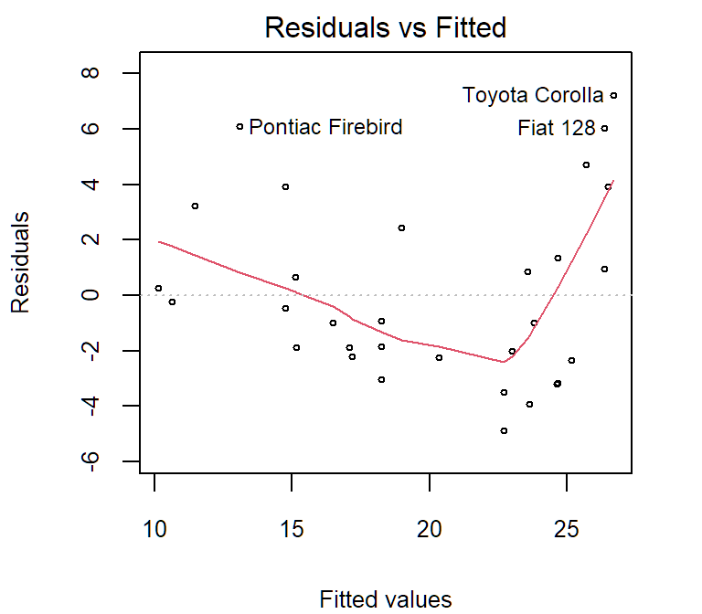

## Scale-Location

**Homoscedasticity**: straight red line

- Residual variance increases with fitted value

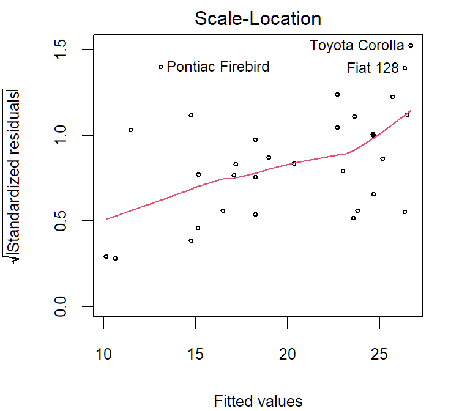

## Q-Q residuals plot

**Normality**: points on diagonal

- Too many residuals in the tails

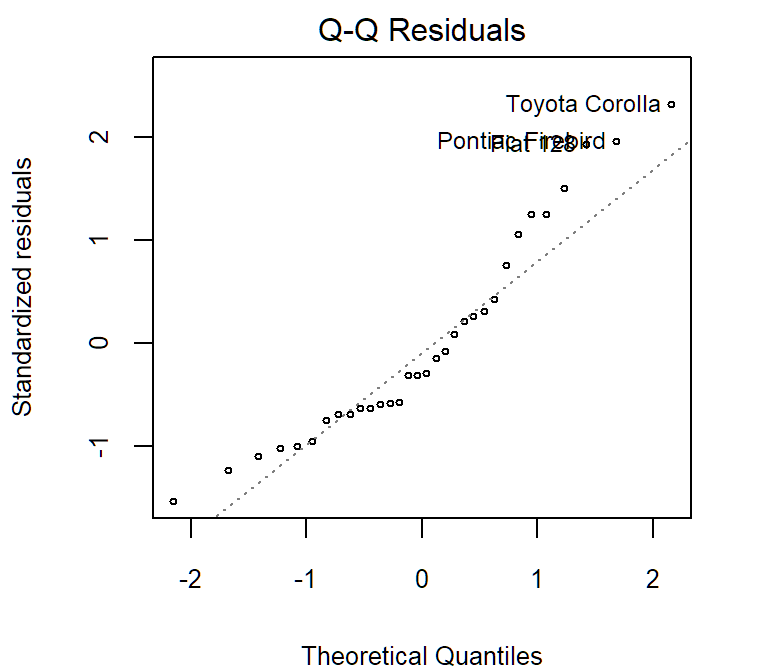

## Residuals vs Leverage

- outlier on \(X\)

**Cook’s distance** values \(>1\) problematic

- outlier on \((X,y)\)

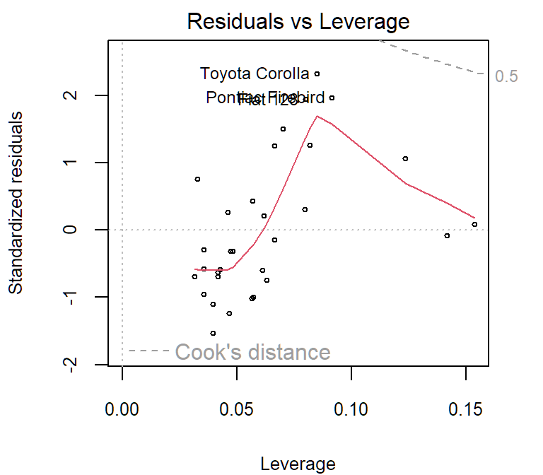

## Non-linearity

## Solutions to non-linearity

Model extensions

- polynomials
- interactions

## Polynomial models

Model including power expansions (quadratic, cubic, quartic, etc.)

\[y=\beta_0+\beta_1x+\beta_2x^2+\beta_3x^3+\dots+\varepsilon\]

The more powers, the more flexible the regression line

- and the higher the risk of overfitting

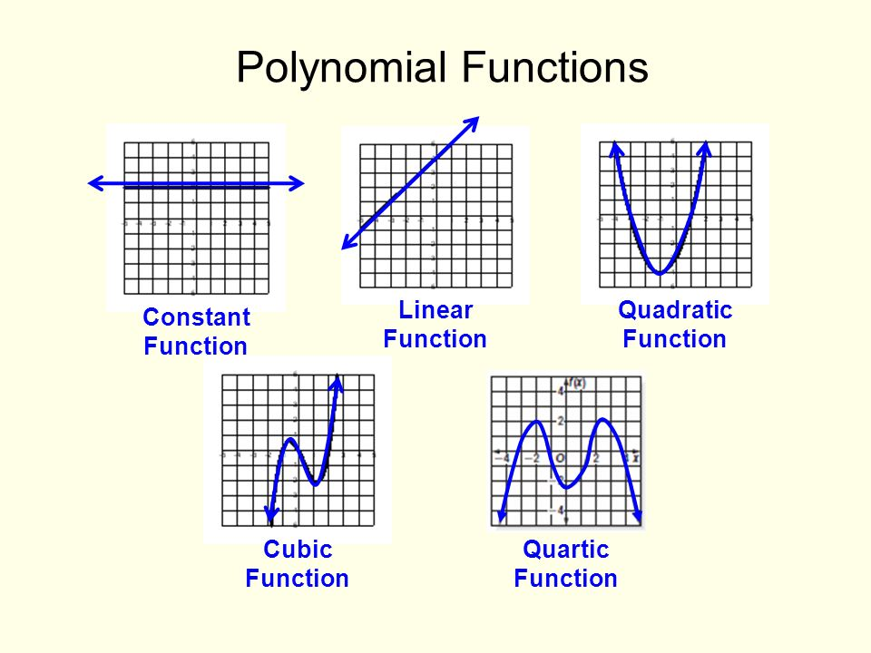

## The `poly()` function

The function `poly(x, degree)` creates orthogonal polynomials

```r
(raw <- poly(1:4, degree = 3, simple = T, raw = T))
     1  2  3
[1,] 1  1  1
[2,] 2  4  8
[3,] 3  9 27
[4,] 4 16 64
cor(raw) %>% round(4)
       1      2      3
1 1.0000 0.9844 0.9514
2 0.9844 1.0000 0.9905
3 0.9514 0.9905 1.0000

(pol <- poly(1:4, degree = 3, simple = T))
              1    2          3
[1,] -0.6708204  0.5 -0.2236068
[2,] -0.2236068 -0.5  0.6708204
[3,]  0.2236068 -0.5 -0.6708204
[4,]  0.6708204  0.5  0.2236068
cor(pol) %>% round(4)
  1 2 3
1 1 0 0
2 0 1 0
3 0 0 1
```

## Quadratic model

```r
summary(lm(mpg ~ poly(disp, 2), mtcars))
```

```
Call:
lm(formula = mpg ~ poly(disp, 2), data = mtcars)

Residuals:
    Min      1Q  Median      3Q     Max
-3.9112 -1.5269 -0.3124  1.3489  5.3946

Coefficients:
               Estimate Std. Error t value Pr(>|t|)
(Intercept)     20.0906     0.5015  40.061  < 2e-16 ***
poly(disp, 2)1 -28.4410     2.8369 -10.025 6.23e-11 ***
poly(disp, 2)2   9.1524     2.8369   3.226   0.0031 **
---
Signif. codes:  0 '***' 0.001 '**' 0.01 '*' 0.05 '.' 0.1 ' ' 1

Residual standard error: 2.837 on 29 degrees of freedom
Multiple R-squared:  0.7927,    Adjusted R-squared:  0.7784
F-statistic: 55.46 on 2 and 29 DF,  p-value: 1.229e-10
```

## Quadratic, cubic and quartic model

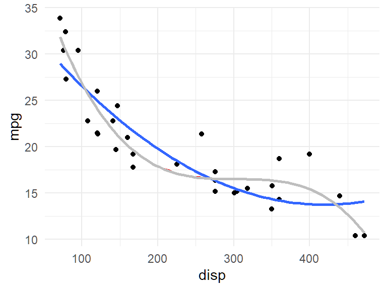

```r
ggplot(mtcars, aes(disp, mpg)) +
  geom_point() +
  geom_smooth(method = "lm", se = FALSE, formula = y ~ poly(x, 2)) +
  geom_smooth(method = "lm", se = FALSE, formula = y ~ poly(x, 3), col = "red") +
  geom_smooth(method = "lm", se = FALSE, formula = y ~ poly(x, 4), col = "grey") +
  theme_minimal()
```

## Model selection

Subsequently testing models (protection against overfitting)

```r
anova(lm(mpg ~ disp, mtcars),
      lm(mpg ~ poly(disp, 2), mtcars),
      lm(mpg ~ poly(disp, 3), mtcars),
      lm(mpg ~ poly(disp, 4), mtcars))
```

```
Analysis of Variance Table

Model 1: mpg ~ disp
Model 2: mpg ~ poly(disp, 2)
Model 3: mpg ~ poly(disp, 3)
Model 4: mpg ~ poly(disp, 4)
  Res.Df    RSS Df Sum of Sq      F    Pr(>F)
1     30 317.16
2     29 233.39  1    83.766 16.337 0.0003961 ***
3     28 138.44  1    94.957 18.520 0.0001975 ***
4     27 138.44  1     0.000  0.000 0.9959922
---
Signif. codes:  0 '***' 0.001 '**' 0.01 '*' 0.05 '.' 0.1 ' ' 1
```

## Residual plots cubic model

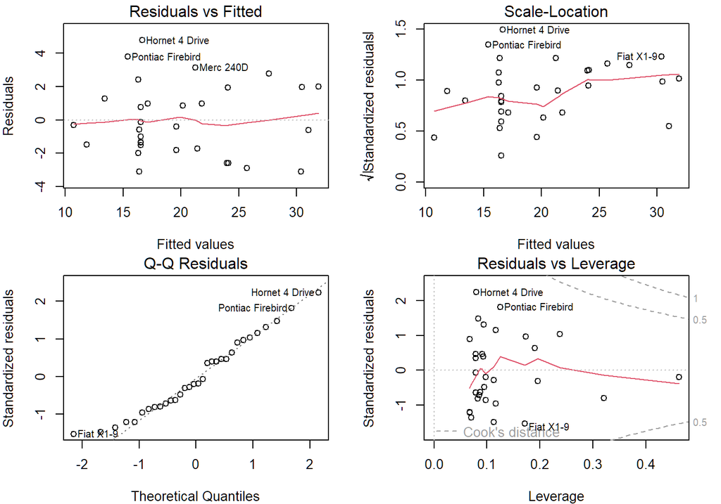

## Splines

Cubic polynomials within regions of \(X\) (boundaries \(\xi\) are called *knots*)

- very flexible in fitting curves to the data
- risk of overfitting with too many knots

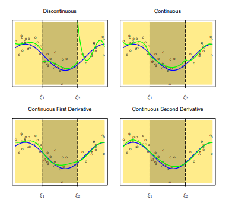

## Fitting splines

B-spline from the package `splines`

```r
bs(x, knots = <position(s) of the knot(s)>)
```

Example with different position of knots

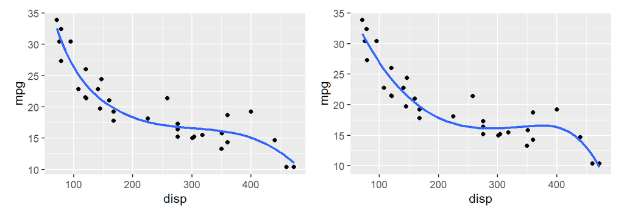

```r
ggplot(mtcars, aes(disp, mpg)) + geom_point() +
  geom_smooth(method = "lm", se = F, formula = y ~ bs(x, knots = 150)) +
ggplot(mtcars, aes(disp, mpg)) + geom_point() +
  geom_smooth(method = "lm", se = F, formula = y ~ bs(x, knots = 350))
```

## Interaction models

## Interpretation slopes

Slope of \(x_1\) varies with values of \(x_2\) and vice-versa

\[y=\beta_0+\beta_1x_1+\beta_2x_2+\beta_{12}x_1x_2+\varepsilon\]

Example: adding `factor(gear)` to the model

```
Analysis of Variance Table

Model 1: mpg ~ disp
Model 2: mpg ~ disp + gear
Model 3: mpg ~ disp * gear
  Res.Df    RSS Df Sum of Sq      F    Pr(>F)
1     30 317.16
2     28 317.01  2     0.147  0.011 0.9890201
3     26 172.87  2   144.139 10.839 0.0003771 ***
---
Signif. codes:  0 '***' 0.001 '**' 0.01 '*' 0.05 '.' 0.1 ' ' 1
```

## Add `gear` as predictor

Effect of `gear` as a `factor`.

- no significant main effects of `gear` (no difference in intercepts)
- highly significant interaction effect (clear difference in slopes)

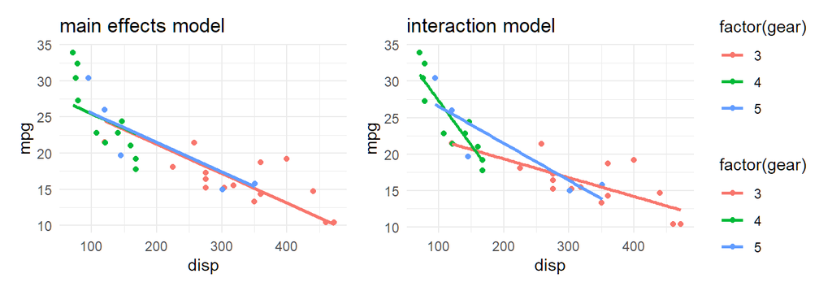

## Residual plots

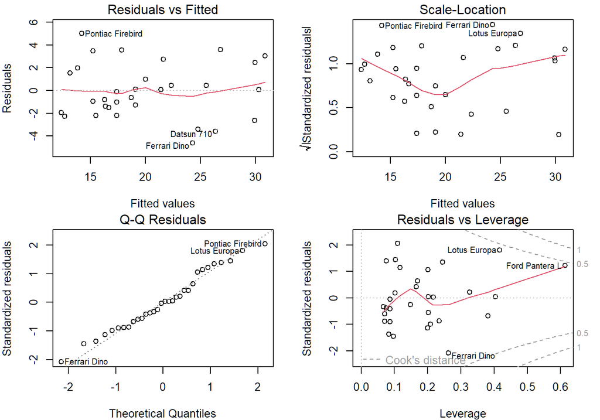

## Heteroscedasticity

## What is heteroscedasticity?

Variance of the residuals is correlated with the fitted values.

- variables are skewed
- error variance correlates with the fitted values
- standard errors and \(p\)-values are biased

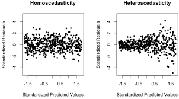

## Resolving heteroscedasticity

Data transformation may solve the problem

- `log` or `sqrt` transformation for variables with right skew

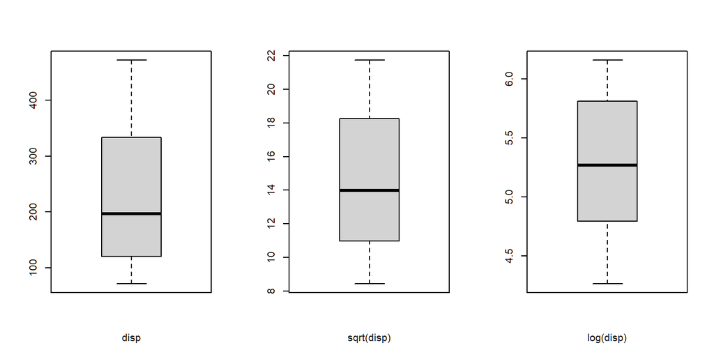

## Improving linearity

Scatter plots after transformation of `disp`

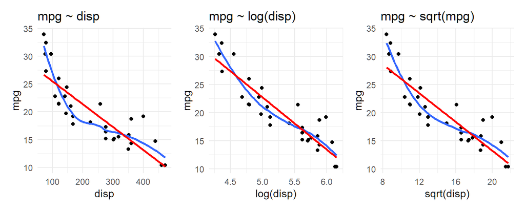

## Multicollinearity

## Detecting multicollinearity

Multicollinearity

- highly correlated (combinations of) predictors
- unreliable parameter estimates and inflated standard errors

Detected with VIF (Variance Inflation Factor)

- VIF = 1 no multicollinearity whatsoever
- VIF > 10 serious multicollinearity

Resolving multicollinearity

- drop or merge predictors
- standardize interacting predictors

## VIF examples

- Too many predictors

```
    cyl    disp      hp    drat      wt    qsec      vs      am   gear4   gear5    carb
18.0210 21.8940 12.9340  4.9763 15.8000  8.0838  5.7913  5.8219  9.2959  5.6484  8.9221
```

- Cubic model with correlated polynomials

```
     disp I(disp^2) I(disp^3)
   294.09   1342.00    420.80
```

- Interaction model (unstandardized disp)

```
      disp      gear4      gear5 disp:gear4 disp:gear5
    3.7805    14.2800     7.9329     8.8487     6.0386
```

- Interaction model (standardized disp)

```
      scale(disp)             gear4             gear5 scale(disp):gear4 scale(disp):gear5
           3.7805            6.8933            1.4940            7.0473            1.5134
```